# 假設檢定和平均值的比較

Hypothesis Testing and Comparison of Means

Author

Tsai, Dai-Rong

# 1 Student’s *t*-test

**TipArguments of `t.test()`**

- `alternative`: alternative hypothesis
  - `"two.sided"` $(H_0: \mu_1 = \mu_2;~~~ H_1: \mu_1 \ne \mu_2)$
  - `"greater"` $~~~(H_0: \mu_1 \le \mu_2;~~~ H_1: \mu_1 > \mu_2)$
  - `"less"` $~~~~~~~~(H_0: \mu_1 \ge \mu_2;~~~ H_1: \mu_1 < \mu_2)$
- `mu = 0`:
  - for one-sample test, true value of the mean
  - for two-sample test, difference in the two means
- `paired = FALSE`: whether two samples are related (paired)
- `var.equal = FALSE`: whether two population variances are equal
- `conf.level = 0.95`: confidence level

See `?t.test` for more details.

## 1.1 One-sample *t*-test

### Exercise (1)

欲調查某廠牌泡麵防腐劑含量是否超標($\le 3$ ppm)， 隨機抽取該廠牌 10 包泡麵，並測量每包泡麵的防腐劑含量。

```r
pres <- read.csv("data/preservative.csv")
str(pres)
```

```
'data.frame':   10 obs. of  1 variable:
 $ ppm: int  3 4 5 3 4 5 4 4 2 5
```

1. 請以「**單尾**檢定」檢驗此泡麵防腐劑含量是否符合政府所制定的國家標準(3 ppm)。

   令該廠牌泡麵的防腐劑平均含量為 $\mu$，欲檢定之假說為：

   $$\begin{cases}
   H_0: \mu \le 3 \text{ ppm} \\
   H_1: \mu > 3 \text{ ppm}
   \end{cases}$$

   ```r
   t.test(pres$ppm, alternative = "greater", mu = 3)
   ```

   ```
    One Sample t-test

   data:  pres$ppm
   t = 2.862, df = 9, p-value = 0.00936
   alternative hypothesis: true mean is greater than 3
   95 percent confidence interval:
    3.323548      Inf
   sample estimates:
   mean of x
         3.9
   ```

   ```r
   # How to get p-value?
   1 - pt(2.862, df = 9)
   ```

   ```
   [1] 0.009359624
   ```

**WarningConclusion**

此廠牌泡麵防腐劑含量之樣本平均值為 3.9 ppm，在顯著水準 0.05 下

- 95% **單尾**信賴區間 (3.32, $\infty$) 未包含 3
- *p*-value = 0.0094 小於顯著水準

可以拒絕 $H_0$。此廠牌泡麵防腐劑平均含量顯著高於政府所制定的國家標準。

2. 請以「**雙尾**檢定」檢驗此泡麵防腐劑含量是否符合政府所制定的國家標準(3 ppm)。

   令該廠牌泡麵的防腐劑平均含量為 $\mu$，欲檢定之假說為：

   $$\begin{cases}
   H_0: \mu = 3 \text{ ppm} \\
   H_1: \mu \ne 3 \text{ ppm}
   \end{cases}$$

   ```r
   t.test(pres$ppm, alternative = "two.sided", mu = 3)
   ```

   ```
    One Sample t-test

   data:  pres$ppm
   t = 2.862, df = 9, p-value = 0.01872
   alternative hypothesis: true mean is not equal to 3
   95 percent confidence interval:
    3.188628 4.611372
   sample estimates:
   mean of x
         3.9
   ```

   ```r
   # How to get p-value?
   (1 - pt(2.862, df = 9)) * 2
   ```

   ```
   [1] 0.01871925
   ```

**WarningConclusion**

此廠牌泡麵防腐劑含量之樣本平均值為 3.9 ppm，在顯著水準 0.05 下

- 95% **雙尾**信賴區間 (3.19, 4.61) 未包含 3
- *p*-value = 0.0187 小於顯著水準

可以拒絕 $H_0$。此廠牌泡麵防腐劑平均含量與政府所制定的國家標準有顯著差異。

## 1.2 Paired two-sample *t*-test

### Exercise (2)

欲探討牙周再生手術是否能改善牙周病人口腔狀況， 研究者收集 10 位牙周病人接受牙周再生手術前後之牙周囊袋深度 (probing pocket depth)。

```r
ppd <- read.csv("data/ppd.csv")
str(ppd)
```

```
'data.frame':   10 obs. of  3 variables:
 $ ppd0: int  10 7 8 7 8 7 8 7 9 8
 $ ppd1: int  3 1 2 2 1 3 3 2 2 3
 $ diff: int  7 6 6 5 7 4 5 5 7 5
```

- `ppd0`: 治療前牙周囊袋深度 (單位: mm)。
- `ppd1`: 治療後牙周囊袋深度 (單位: mm)。
- `diff`: 治療前減治療後的牙周囊袋深度 (單位: mm)。

牙周囊袋深度變化是指同一位病人在治療前後的變化， 因此同一病人 2 次牙周囊袋深度具有相關性。

令治療前與治療後牙周囊袋平均深度分別為 $\mu_1$ 和 $\mu_2$，欲檢定之假說為：

$$\begin{cases}
H_0: \mu_1 - \mu_2 \le 0 \\
H_1: \mu_1 - \mu_2 > 0
\end{cases}$$

進行 paired *t*-test 可使用兩種語法，結果一致:

```r
# general interface
t.test(ppd$ppd0, ppd$ppd1, alternative = "greater", paired = TRUE)

# formula interface
t.test(Pair(ppd0, ppd1) ~ 1, data = ppd, alternative = "greater")
```

```
    Paired t-test

data:  ppd$ppd0 and ppd$ppd1
t = 17.015, df = 9, p-value = 1.879e-08
alternative hypothesis: true mean difference is greater than 0
95 percent confidence interval:
 5.085915      Inf
sample estimates:
mean difference
            5.7
```

**WarningConclusion**

接受牙周再生手術的牙周病人，牙周囊袋深度平均減少 5.7 mm，在顯著水準 0.05 下

- 95% **單尾**信賴區間 (5.09, $\infty$) 未包含 0
- *p*-value = $1.88 \times 10^{-8}$ 小於顯著水準

可以拒絕 $H_0$。接受牙周再生手術能顯著減少牙周囊袋平均深度。

**Note**

將同一病人治療前後之牙周囊袋深度相減，再進行 one-sample *t*-test，結果一致。

```r
t.test(ppd$diff, alternative = "greater")
```

```
    One Sample t-test

data:  ppd$diff
t = 17.015, df = 9, p-value = 1.879e-08
alternative hypothesis: true mean is greater than 0
95 percent confidence interval:
 5.085915      Inf
sample estimates:
mean of x
      5.7
```

## 1.3 Independent two-sample *t*-test

- 兩母體變異數相同 ($\sigma_1^2 = \sigma_2^2 = \sigma^2$)
  - Sample variances:
    $$s_1^2 = \frac{\sum_{i = 1}^{n_1} (X_i - \bar{X})^2}{n_1 - 1} ~~~\text{and}~~~
    s_2^2 = \frac{\sum_{j = 1}^{n_2} (Y_j - \bar{Y})^2}{n_2 - 1}$$
  - Pooled sample variance:
    $$s_p^2 = \frac{\sum_{i=1}^{n_1}(X_i-\bar{X})^2 + \sum_{j=1}^{n_2}(Y_j-\bar{Y})^2}{n_1+n_2-2}
    = \frac{(n_1-1)s_1^2 + (n_2-1)s_2^2}{n_1+n_2-2}$$
  - Test statistic:
    $$T = \frac{\bar{X} -\bar{Y}}{s_p \sqrt{\frac{1}{n_1} + \frac{1}{n_2}}} \sim t_{df}, ~~~
    df = n_1 + n_2 - 2$$
- 兩母體變異數不同 ($\sigma_1^2 \ne \sigma_2^2$) — **Welch’s *t*-test**
  - Test statistic:
    $$T = \frac{\bar{X} -\bar{Y}}{\sqrt{\frac{s_1^2}{n_1} + \frac{s_2^2}{n_2}}} \sim t_{df}, ~~~
    df = \frac{(\frac{s_1^2}{n_1} + \frac{s_2^2}{n_2})^2}
    {\frac{(\frac{s_1^2}{n_1})^2}{n_1-1} +
    \frac{(\frac{s_2^2}{n_2})^2}{n_2-1}}$$

### Exercise (3)

欲研究懷孕婦女吸菸是否會影響嬰兒體重， 隨機抽取 14 名吸菸的孕婦和 15 名無吸菸的孕婦，測量嬰兒出生體重。

```r
smk_wt <- readxl::read_xlsx("data/smoking_birth_weight.xlsx")
str(smk_wt)
```

```
tibble [29 × 2] (S3: tbl_df/tbl/data.frame)
 $ smoking    : chr [1:29] "smokers" "smokers" "smokers" "smokers" ...
 $ birthweight: num [1:29] 3.18 2.74 2.9 3.27 3.65 3.42 3.23 2.86 3.6 3.65 ...
```

檢定前先進行基本的探索性分析：

```r
table(smk_wt$smoking)
```

```
nonsmokers    smokers
        15         14
```

```r
aggregate(birthweight ~ smoking, data = smk_wt,
          FUN = \(x) c(Mean = mean(x), SD = sd(x)))
```

```
     smoking birthweight.Mean birthweight.SD
1 nonsmokers        3.6266667      0.3584025
2    smokers        3.1742857      0.4631450
```

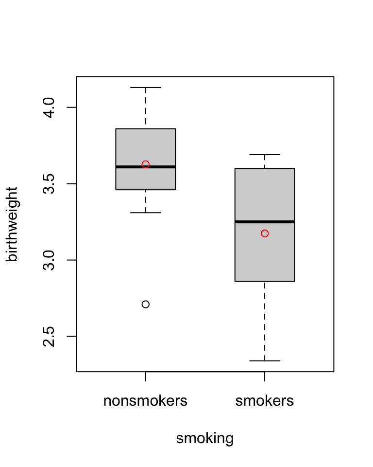

```r
boxplot(birthweight ~ smoking, data = smk_wt, boxwex = 0.5)
points(aggregate(birthweight ~ smoking, data = smk_wt, FUN = mean), col = "red")
```

令吸菸與無吸菸孕婦生下的嬰兒平均體重分別為 $\mu_1$ 和 $\mu_2$，欲檢定之假說為：

$$\begin{cases}
H_0: \mu_1 = \mu_2 \\
H_1: \mu_1 \ne \mu_2
\end{cases}$$

**NoteHow to know $\sigma_1^2 = \sigma_2^2$ or not?**

#### *F*-test of equality of variances (two samples)

$$\begin{cases}
H_0: \sigma_1 = \sigma_2 \\
H_1: \sigma_1 \ne \sigma_2
\end{cases}$$

```r
var.test(birthweight ~ smoking, data = smk_wt)
```

```
    F test to compare two variances

data:  birthweight by smoking
F = 0.59884, num df = 14, denom df = 13, p-value = 0.353
alternative hypothesis: true ratio of variances is not equal to 1
95 percent confidence interval:
 0.1943104 1.8036316
sample estimates:
ratio of variances
         0.5988364
```

變異數檢定之 *p*-value = 0.353，在顯著水準 0.05 下無法拒絕 $H_0$。 吸菸與無吸菸孕婦生下的嬰兒體重變異數無顯著差異。 因此進行 *t*-test 時需設定 `var.equal = TRUE`:

```r
t.test(birthweight ~ smoking, data = smk_wt, var.equal = TRUE)
```

```
    Two Sample t-test

data:  birthweight by smoking
t = 2.9535, df = 27, p-value = 0.006437
alternative hypothesis: true difference in means between group nonsmokers and group smokers is not equal to 0
95 percent confidence interval:
 0.1381077 0.7666542
sample estimates:
mean in group nonsmokers    mean in group smokers
                3.626667                 3.174286
```

**WarningConclusion**

*p*-value = 0.006437，在顯著水準 0.05 下可以拒絕 $H_0$。

吸菸與無吸菸孕婦生下的嬰兒平均體重有顯著差異。

# 2 Analysis of Variance (ANOVA)

## 2.1 Prerequisites

1. Independence of observations
2. Normality
   - Check using **Shapiro-Wilk test**: `shapiro.test()`
3. Equality of variances (Homoscedasticity)
   - Check using
     - **Levene’s test**: `car::leveneTest()`
     - **Bartlett’s test**: `bartlett.test()`

**Note**

- Bartlett’s test 對資料的常態性較為敏感； 當資料偏離常態分布時，可能錯誤判斷變異數不相同 (Type I error)。
- Levene’s test 對資料偏離常態分布較為穩健； 然而，當常態分布假設成立時，可能錯誤判斷變異數相同 (Type II error)， 使其檢定力 (power) 低於 Bartlett’s test。
- 若資料明顯違反常態性假設, 可改用無母數 (non-parametric) 檢定方法
  - **Kruskal-Wallis test**: `kruskal.test()`
- 若資料近似常態分布，但變異數不相等, 可改用
  - **Welch’s ANOVA**: `oneway.test(..., var.equal = FALSE)`

## 2.2 事後檢定 (post-hoc test)

若有 3 組獨立樣本，需進⾏ $C_2^3 = 3$ 次成對比較。 令一次成對比較犯錯的可容許機率為$\alpha^*$，整體犯錯的可容許機率為$\alpha$，則

$$\begin{aligned}
\alpha &= P(\text{3次成對比較至少犯一錯}) \\
&= 1 - P(\text{3次成對比較皆不犯錯}) \\
&= 1 - (1 - \alpha^*)^3 \\
&= 3\alpha^* - 3\alpha^{*2} + \alpha^{*3} \approx 3\alpha^*
\end{aligned}$$

為了避免型 I 誤差膨脹，可將一次成對比較犯錯的機率 $\alpha^*$ 設為 $\frac{\alpha}{3}$ (等同於將每一次成對比較的 *p*-value 乘以3)， 此做法即為 Bonferroni correction。

### Exercise (4)

欲探討三種類型的鐮刀型紅血球疾病(sickle cell disease) 患者的血紅素濃度是否有差異，研究者收集 41 位患者 並記錄他們的疾病類型 (Hb SC, Hb S/b, Hb SS) 與血紅素濃度。

```r
hb <- readxl::read_xlsx("data/hemoglobin.xlsx")
str(hb)
```

```
tibble [41 × 2] (S3: tbl_df/tbl/data.frame)
 $ group: chr [1:41] "Hb_SC" "Hb_SC" "Hb_SC" "Hb_SC" ...
 $ hb   : num [1:41] 10.7 11.3 11.5 11.6 11.7 11.8 12 12.1 12.3 12.6 ...
```

```r
table(hb$group)
```

```
Hb_Sb Hb_SC Hb_SS
   10    15    16
```

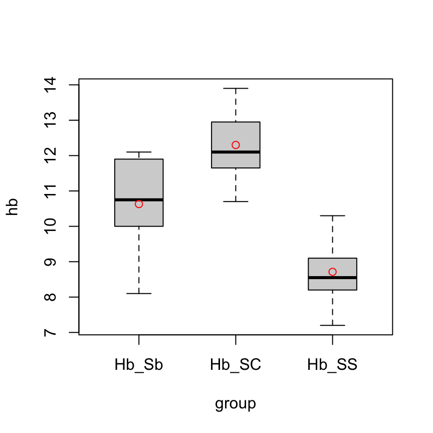

```r
boxplot(hb ~ group, data = hb, boxwex = 0.5)
points(aggregate(hb ~ group, data = hb, FUN = mean), col = "red")
```

令三種類型的鐮刀型紅血球疾病患者的血紅素平均濃度分別為 $\mu_{sb}$、$\mu_{sc}$、和 $\mu_{ss}$，欲檢定之假說為：

$$\begin{cases}
H_0: \mu_{sb} = \mu_{sc} = \mu_{ss} \\
H_1: \text{at least one } \mu_i \ne \mu_j ~~~\text{for}~~~
i,j = \{sb, sc, ss\}
\end{cases}$$

```r
hb_aov <- aov(hb ~ group, data = hb)
```

- Test for normality

  $$\begin{cases}
  H_0: \text{data come from a normal distribution} \\
  H_1: \text{data do not come from a normal distribution}
  \end{cases}$$

  ```r
  shapiro.test(hb_aov$residuals)
  ```

  ```
    Shapiro-Wilk normality test

  data:  hb_aov$residuals
  W = 0.96544, p-value = 0.2427
  ```

- Test for equality of variances

  $$\begin{cases}
  H_0: \sigma^2_{sb} = \sigma^2_{sc} = \sigma^2_{ss} \\
  H_1: \text{at least one } \sigma^2_i \ne \sigma^2_j ~~~\text{for}~~~
  i,j = \{sb, sc, ss\}
  \end{cases}$$

  ```r
  car::leveneTest(hb ~ group, data = hb)
  ```

  ```
  Levene's Test for Homogeneity of Variance (center = median)
        Df F value Pr(>F)
  group  2  0.8747 0.4252
        38
  ```

  ```r
  bartlett.test(hb ~ group, data = hb)
  ```

  ```
    Bartlett test of homogeneity of variances

  data:  hb by group
  Bartlett's K-squared = 2.1251, df = 2, p-value = 0.3456
  ```

- ANOVA

  ```r
  summary(hb_aov)
  ```

  ```
              Df Sum Sq Mean Sq F value   Pr(>F)
  group        2  99.89   49.94      50 2.28e-11 ***
  Residuals   38  37.96    1.00
  ---
  Signif. codes:  0 '***' 0.001 '**' 0.01 '*' 0.05 '.' 0.1 ' ' 1
  ```

  ```r
  # How to get p-value?
  1 - pf(50, df1 = 2, df2 = 38)
  ```

  ```
  [1] 2.28132e-11
  ```

**WarningConclusion**

*p*-value = $2.28 \times 10^{-11}$，在顯著水準 0.05 下可以拒絕 $H_0$。

三種類型的鐮刀型紅血球疾病患者的血紅素平均濃度並非完全相同。

為了找出哪些類型的鐮刀型紅血球疾病的血紅素平均濃度有差異，需進行事後檢定。

- Bonferroni correction

  ```r
  pairwise.t.test(hb$hb, hb$group, p.adjust.method = "bonf")
  ```

  ```
    Pairwise comparisons using t tests with pooled SD

  data:  hb$hb and hb$group

        Hb_Sb   Hb_SC
  Hb_SC 0.00064 -
  Hb_SS 8.4e-05 1.1e-11

  P value adjustment method: bonferroni
  ```

  > 這裡的 *p*-values 已經過調整 (乘以成對比較的次數)， 判斷時還是以原本設定的顯著水準 (e.g. 0.05) 當作標準。

**WarningConclusion**

在顯著水準 0.05 下，任兩種類型的鐮刀型紅血球疾病的血紅素平均濃度皆有顯著差異。

**Note**

Bonferroni correction 偏保守 (高估 *p*-value)，較不容易看出成對比較的差別。可改用其他校正方法:

```r
p.adjust.method = "..."
```

- `"holm"`: Holm (1979)
- `"hochberg"`: Hochberg (1988)
- `"hommel"`: Hommel (1988)
- `"BH"` (alias `"fdr"`): Benjamini & Hochberg (1995)
- `"BY"`: Benjamini & Yekutieli (2001)

或是使用 Tukey’s HSD (honestly significant difference) test:

```r
TukeyHSD(hb_aov)
```

```
  Tukey multiple comparisons of means
    95% family-wise confidence level

Fit: aov(formula = hb ~ group, data = hb)

$group
               diff        lwr        upr     p adj
Hb_SC-Hb_Sb  1.6700  0.6748973  2.6651027 0.0006147
Hb_SS-Hb_Sb -1.9175 -2.9000852 -0.9349148 0.0000819
Hb_SS-Hb_SC -3.5875 -4.4635296 -2.7114704 0.0000000
```